# Assignment 2

Mauricio Reis | D21125621

Complete the following project using R Markdown and ensure that your code and output are readable in the html file.

### The `veteran` dataset

```r
library(survival)
?veteran
```

### Questions

1. Estimate and plot $S(t)$ for the two `prior` groups using the Kaplan-Meier estimator and find $\Pr(T > 200)$ for an individual with `prior` = 0 and `prior` = 10. [**25 marks**]

```r
SKM <- survfit(Surv(time, status) ~ prior, data = veteran)
summary(SKM)
```

```
## Call: survfit(formula = Surv(time, status) ~ prior, data = veteran)
##
##                 prior=0
##  time n.risk n.event survival std.err lower 95% CI upper 95% CI
##     1     97       1   0.9897  0.0103      0.96979       1.0000
##     3     96       1   0.9794  0.0144      0.95151       1.0000
##     4     95       1   0.9691  0.0176      0.93523       1.0000
##     7     94       3   0.9381  0.0245      0.89141       0.9873
##     8     91       2   0.9175  0.0279      0.86438       0.9739
##    10     89       1   0.9072  0.0295      0.85128       0.9668
##    13     88       2   0.8866  0.0322      0.82569       0.9520
##    15     86       1   0.8763  0.0334      0.81316       0.9443
##    18     85       2   0.8557  0.0357      0.78852       0.9285
##    19     83       1   0.8454  0.0367      0.77639       0.9205
##    20     82       1   0.8351  0.0377      0.76437       0.9123
```

[output cut: 99 more lines]

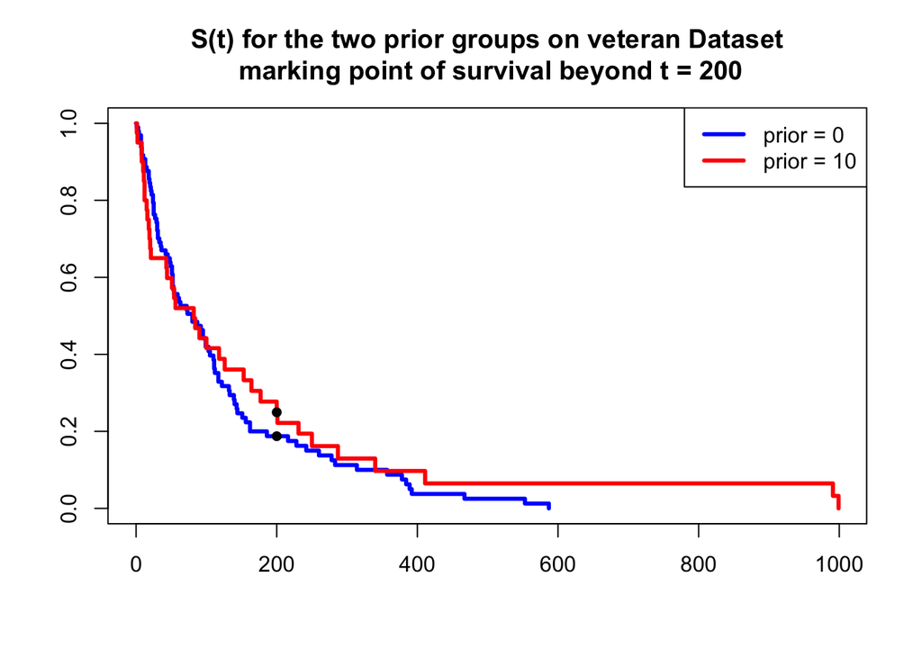

```r
plot(SKM,
     col = c("blue", "red"),
     lwd = 3,
     main = "S(t) for the two prior groups on veteran Dataset\n marking point of survival beyond t = 200")

legend("topright",
       c("prior = 0", "prior = 10"),
       lty = 1,
       lwd = 3,
       col = c("blue", "red"))
S_200_prior0 <- summary(SKM, times = 200)$surv[1]
S_200_prior10 <- summary(SKM, times = 200)$surv[2]
points(200, y = S_200_prior0, type = "p", col = "black", pch = 16)
points(200, y = S_200_prior10, type = "p", col = "black", pch = 16)
```

```r
print(paste("Pr(T > 200) for prior 0:", signif(S_200_prior0, digits = 3)))
```

```
## [1] "Pr(T > 200) for prior 0: 0.187"
```

```r
print(paste("Pr(T > 200) for prior 10:", signif(S_200_prior10, digits = 3)))
```

```
## [1] "Pr(T > 200) for prior 10: 0.25"
```

2. Test whether there is a significant difference between the survival functions of the two `prior` groups and draw you conclusions. [**25 marks**]

```r
WT <- survdiff(Surv(time, status) ~ prior, data = veteran, rho = 1)
WT
```

```
## Call:
## survdiff(formula = Surv(time, status) ~ prior, data = veteran,
##     rho = 1)
##
##           N Observed Expected (O-E)^2/E (O-E)^2/V
## prior=0  97     47.6     48.2   0.00694    0.0366
## prior=10 40     19.8     19.3   0.01736    0.0366
##
##  Chisq= 0  on 1 degrees of freedom, p= 0.8
```

*conclusions here.* First of all, as on the previous plot we’ve noticed that lines crossed, we concluded that we should use Wilcoxon test (rho=1) instead of Log-rank.  
From this comparison, we got a p-value of 0.8 meaning that we failed to reject the null hypotesis as there is no statistically relevant difference between the survival functions for prior 0 (patient did not receive prior therapy) and prior 10 (patient received prior therapy)

3. Estimate the Weibull PH Model (using the **SurvRegCensCov** package) using the `age` and `prior` covariates. [**25 marks**]

```r
library(SurvRegCensCov)
WR <- WeibullReg(Surv(time, status) ~ age + factor(prior), data = veteran)
WR
```

```
## $formula
## Surv(time, status) ~ age + factor(prior)
##
## $coef
##                     Estimate          SE
## lambda           0.009482902 0.006434437
## gamma            0.866673038 0.059003884
## age              0.009555038 0.009604443
## factor(prior)10 -0.183794247 0.197544232
##
## $HR
##                       HR        LB       UB
## age             1.009601 0.9907735 1.028786
## factor(prior)10 0.832107 0.5649750 1.225545
##
## $ETR
##                       ETR        LB       UB
## age             0.9890356 0.9678972 1.010636
## factor(prior)10 1.2362328 0.7931037 1.926951
##
## $summary
##
## Call:
## survival::survreg(formula = formula, data = data, dist = "weibull")
##                   Value Std. Error     z       p
## (Intercept)      5.3749     0.6635  8.10 5.5e-16
## age             -0.0110     0.0110 -1.00   0.317
## factor(prior)10  0.2121     0.2265  0.94   0.349
## Log(scale)       0.1431     0.0681  2.10   0.036
##
## Scale= 1.15
##
## Weibull distribution
## Loglik(model)= -747.1   Loglik(intercept only)= -748.1
##  Chisq= 2.05 on 2 degrees of freedom, p= 0.36
## Number of Newton-Raphson Iterations: 5
## n= 137
```

4. Create an R function estimating the hazard function of the Weibull PH model and, using the estimates obtained above, and plot the hazard curve for an individual with `age` = 30 and `prior` = 10. [**25 marks**]

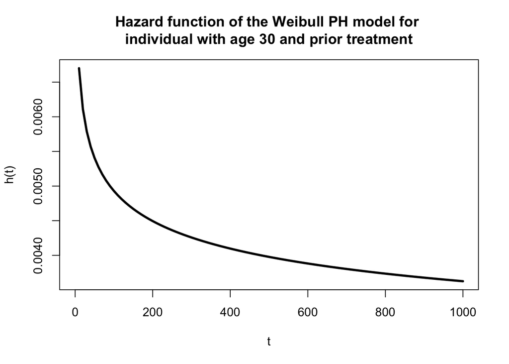

```r
h_weib <- function(x, lambda, gamma, beta_age, beta_prior, x_age, x_prior) {
  lambda * gamma * x^(gamma-1) * exp(beta_age * x_age + beta_prior * x_prior)
}
lambdaVet <- WR$coef[1, 1]
gammaVet <- WR$coef[2, 1]
beta_ageVet <- WR$coef[3, 1]
beta_priorVet <- WR$coef[4, 1]

curve(
  h_weib(x, lambda = lambdaVet, gamma = gammaVet, beta_age = beta_ageVet,
        beta_prior = beta_priorVet, x_age = 30, x_prior = 1),
      from = 0, to = 1000, lwd = 3,
      ylab = 'h(t)', xlab = 't', main = "Hazard function of the Weibull PH model for \nindividual with age 30 and prior treatment")
```